# Machine Learning Project

medianvoter

6 November 2018

## Executive Summary

In this report I use machine learning to determine the activity type. The data are various measurements of participants performing bicep curls correctly (Class A), and wrongly (Classes B-E), and this report aims to develop a model to predict which type class of activity a person performed based on measurements made by accelerometers on the belt, forearm, arm, and dumbell. I find that quadratic discriminant analysis is the most predictive model, with an accuracy rate of 0.897 on the cross-validation set. As the QDA model is selected specifically because it performed well on the cross-validation set, I expect out-of-sample accuracy to be smaller and out-of-sample error to be greater (> 0.103). The github repository is [here](https://github.com/medianvoter/machine-learning-project).

## Data Loading and Preprocessing

I first load the necessary packages and download the file (code not shown). I load both training and test files and check their dimensions to ensure they match. I also visually inspect the training file to understand the data.

```r
table(data$classe) # Outcome
```

```
##
##    A    B    C    D    E
## 5580 3797 3422 3216 3607
```

```r
str(test)
```

Visual inspection and running `str(test)` (output not shown) reveals that some data cleaning is necessary. First, there are variables that look numeric but for the fact that some take the value of “#DIV/0!”. Experience with Excel tells me that this is a divide-by-zero error message. I choose to replace these numbers with 0. In order to ensure that my eventual prediction model can use the test data, I perform the same data processing step on the test data. Note, however, that I do not take extract information from the test data; the test data is processed according to the conditions of the training data.

```r
# Replacing "#DIV/0!" with "0"; converting them from factors to to characters
# first as it is easier to handle
variables <- names(data)[6:159]
for(v in variables) {
    if(is.factor(data[[v]])) {
        data[[v]] <- as.character(data[[v]])
        test[[v]] <- as.character(test[[v]]) ##
    }
    if(is.character(data[[v]])) {
        data[[v]][data[[v]] == "#DIV/0!"] <- "0"
        data[[v]] <- as.numeric(data[[v]])
        test[[v]][test[[v]] == "#DIV/0!"] <- "0"
        test[[v]] <- as.numeric(test[[v]])
    }
}
```

Next, I examine missing values:

```r
table(apply(data, 2, function(x) {mean(is.na(x))})) # many have close to 97.9% na
```

```
##
##                 0 0.979308938946081                 1
##                59               100                 1
```

As shown above, missing values are a problem. Many variables are > 97.9% missing, but the rest of the variables have no missing values. As imputing so many values would probably add more noise than information, I choose to drop those variables.

```r
variables <- names(data)
for(v in variables) {
   if(mean(is.na(data[[v]])) > 0.9) {
       data <- select(data, -v)
       test <- select(test, -v)
   }
}
table(apply(data, 2, function(x) {mean(is.na(x))}))
```

```
##
##  0
## 59
```

After such processing there are no missing values in the training data.

```r
dim(data)
```

```
## [1] 19622    59
```

This leaves us with 19,622 observations and 59 variables. Next, I partition 30% of the training data for cross-validation/model selection. For simplicity, I use the same 30% for cross validation, instead of performing K-fold cross validation.

```r
set.seed(8675309)
inTrain <- createDataPartition(y = data$classe, p = 0.7, list = F)
training <- data[inTrain, ]
cv <- data[-inTrain, ]
```

## Model Building

Next, I perform some exploratory analysis. Unfortunately, there are too many variables and observations to show meaningful plots. Looking at the variables, I developed a sense of which variables provide no predictive value, and I used plots to confirm that suspicion. An example is shown below.

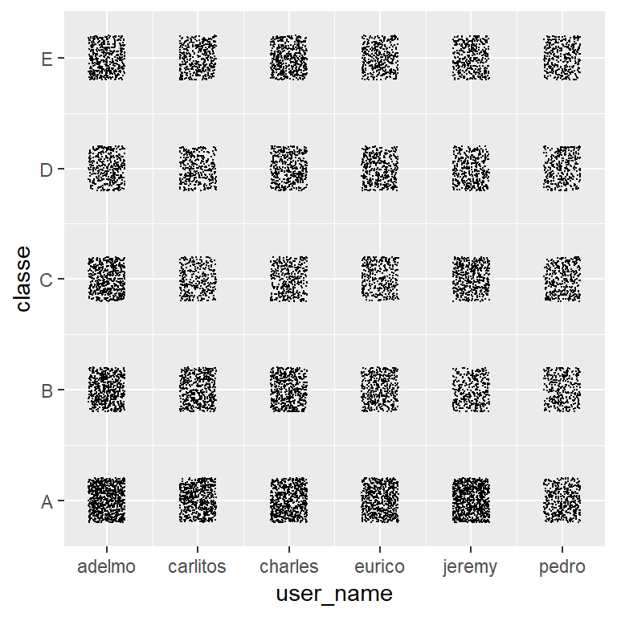

```r
qplot(jitter(as.numeric(training$user_name)), jitter(as.numeric(training$classe)), size = I(0.01)) +
    scale_x_continuous(name = "user_name", breaks = c(1, 2, 3, 4, 5, 6),
                       labels = c("adelmo", "carlitos", "charles", "eurico", "jeremy", "pedro")) +
    scale_y_continuous(name = "classe",
                       breaks = c(1, 2, 3, 4, 5), labels = c("A", "B", "C", "D", "E"))
```

As shown above, it is not entirely clear whether the user’s name has a large impact on the outcome. Moreover, there is no guarantee that the test data will consist of the same users in the training data. Thus, I do not use *user_name* as a predictor. I also drop similar variables to do with the timestamp and window. Thus, I select the predictors.

```r
predictors <- names(training)[7:59]
```

Next, I examine a variety of prediction models: trees, linear discriminant analysis, and quadratic discriminant analysis.

### Trees

I first examine classification and regression trees.

```r
cart <- train(classe ~ ., method = "rpart", data = select(training, predictors))
print(cart$finalModel)
```

```
## n= 13737
##
## node), split, n, loss, yval, (yprob)
##       * denotes terminal node
##
##  1) root 13737 9831 A (0.28 0.19 0.17 0.16 0.18)
##    2) roll_belt< 130.5 12593 8695 A (0.31 0.21 0.19 0.18 0.11)
##      4) pitch_forearm< -33.95 1095    5 A (1 0.0046 0 0 0) *
##      5) pitch_forearm>=-33.95 11498 8690 A (0.24 0.23 0.21 0.2 0.12)
##       10) magnet_dumbbell_y< 426.5 9585 6853 A (0.29 0.18 0.24 0.19 0.11)
##         20) roll_forearm< 122.5 5944 3491 A (0.41 0.18 0.19 0.17 0.057) *
##         21) roll_forearm>=122.5 3641 2431 C (0.077 0.17 0.33 0.23 0.19) *
##       11) magnet_dumbbell_y>=426.5 1913  949 B (0.04 0.5 0.042 0.22 0.2) *
##    3) roll_belt>=130.5 1144    8 E (0.007 0 0 0 0.99) *
```

```r
confusionMatrix(predict(cart), training$classe)$overall[1]
```

```
##  Accuracy
## 0.4988717
```

As shown above, the model never predicts the outcome D. Furthermore, the model has poor training set accuracy (0.499).

### Linear Discriminant Analysis

```r
lda <- train(classe ~ ., data = select(training, predictors), method = "lda")
confusionMatrix(predict(lda), training$classe)$overall[1]
```

```
##  Accuracy
## 0.7033559
```

As shown, LDA has relatively good training set accuracy (0.703).

### Quadratic Discriminant Analysis

```r
qda <- train(classe ~ ., data = select(training, predictors), method = "qda")
confusionMatrix(predict(qda), training$classe)$overall[1]
```

```
##  Accuracy
## 0.9022348
```

As shown, QDA has the best raining set accuracy thus far (0.902).

### Stacking

```r
cartPred <- predict(cart, newdata = cv) # needed for stacking
ldaPred <- predict(lda, newdata = cv)
qdaPred <- predict(qda, newdata = cv)

combinedData <- data.frame(cartPred, qdaPred, ldaPred, classe = cv$classe)
combined <- train(classe ~ ., method = "gam", data = combinedData)
combinedPred <- predict(combined, combinedData)
confusionMatrix(combinedPred, combinedData$classe)$overall[1]
```

```
##  Accuracy
## 0.4453696
```

Surprisingly, stacking the models results in a far worse training set accuracy (0.445).

Please note that I also tried random forest, boosting, and naive Bayes, but they took too long to run on my computer.

## Cross Validation and Model Selection

Next, I use the cross-validation set for model selection. As the models are tuned to the training set, using training set accuracy would be an improper way to select the model. Thus, I use model accuracy on the cross-validation set.

```r
confusionMatrix(cartPred, cv$classe)$overall[1]
```

```
##  Accuracy
## 0.4917587
```

```r
confusionMatrix(ldaPred, cv$classe)$overall[1]
```

```
##  Accuracy
## 0.7036534
```

```r
confusionMatrix(qdaPred, cv$classe)$overall[1]
```

```
##  Accuracy
## 0.8971963
```

```r
confusionMatrix(combinedPred, cv$classe)$overall[1]
```

```
##  Accuracy
## 0.4453696
```

As shown above, QDA is the best predictor, with 0.897 accuracy in the cross-validation set.

## Expected Out of Sample Error

I expect out-of-sample error to be higher and out-of-sample accuracy to be lower (< 0.897). That is because I already used the cross-validation set to choose the best model, so this model is already optimized to the cross-validation set. Thus, it is likely that out-of-sample error is higher (> 0.103) and out-of-sample accuracy to be lower (< 0.897).

## Predictions

Next, I perform predictions on the test data.

```r
testPred <- predict(qda, newdata = test)
for(i in 1:20) print(paste(i, ":", testPred[i]))
```

```
## [1] "1 : A"
## [1] "2 : A"
## [1] "3 : B"
## [1] "4 : A"
## [1] "5 : A"
## [1] "6 : E"
## [1] "7 : D"
## [1] "8 : B"
## [1] "9 : A"
## [1] "10 : A"
## [1] "11 : B"
## [1] "12 : C"
## [1] "13 : B"
## [1] "14 : A"
## [1] "15 : E"
## [1] "16 : E"
## [1] "17 : A"
## [1] "18 : B"
## [1] "19 : B"
## [1] "20 : B"
```

Surprisingly entering the predictions into the quiz yields an accuracy of 0.95, higher than expected.

## Conclusion

I found that quadratic discriminant analysis is the most accurate predictive model, with an accuracy rate of 0.897 on the cross-validation set. As the QDA model is selected specifically because it performed well on the cross-validation set, I expect out-of-sample accuracy to be smaller and out-of-sample error to be greater (> 0.103). However, test set prediction accuracy (0.95) exceeded my expectations.

Thanks for reading!